# Dans quelle mesure les habitudes d’écoute musicale (fréquence et genres écoutés) influencent-elles la santé mentale auto-déclarée chez les individus (anxiété, dépression, insomnie et TOC) ?

BARTHÉLÉMY Bastien JOSEPH Théo CALLEGARI Illan

# 1 **Introduction**

La **musique occupe une place centrale** dans notre quotidien. Que ce soit pour se détendre, se concentrer, extérioriser des émotions ou simplement par plaisir, elle est présente à toutes les étapes de la vie.  
Parallèlement, les **troubles psychologiques tels que l’anxiété, la dépression ou les troubles du sommeil sont en constante progression**, notamment chez les jeunes générations. Face à ce constat, une interrogation naturelle émerge :

> *La musique peut-elle influencer notre santé mentale ?* *Plus précisément, dans quelle mesure les habitudes d’écoute musicale (fréquence et genres écoutés) influencent-elles les troubles psychologiques auto-évalués tels que la dépression, l’anxiété, l’insomnie ou les TOC ?*

Notre travail s’est organisé de cette façon :

- Une première partie de **nettoyage et préparation** des données,
- Une partie de statistiques descriptives des variables intéressantes,
- Puis une série de **modèles économétriques** testant le lien entre musique et santé mentale,
- Enfin, une réflexion sur la **validité des résultats**, notamment autour des problèmes d’**endogénéité**.

L’objectif de ce travail n’est pas de prédire parfaitement les troubles psychologiques, mais plutôt d’analyser les **relations potentielles** entre les habitudes d’écoute musicale et la santé mentale, à travers des outils statistiques et économétriques.

## 1.1 📊 Présentation de la base de données :

La base de données que nous allons étudier a été remplie par des **participants volontaires anonymes** dans le cadre d’un questionnaire en ligne. Nous commencerons donc par un **nettoyage des données**, visant à supprimer les **valeurs aberrantes** et les **valeurs manquantes**. De plus, nous avons choisi de convertir certaines **variables ordonnées**, notamment celles liées à la fréquence d’écoute par genre musical, en **variables quantitatives** afin de pouvoir les intégrer dans nos analyses économétriques.

## 1.2 📈 Statistiques descriptives :

Avant de passer à l’analyse économétrique, nous présentons ci-dessous quelques **statistiques descriptives** sur les principales *variables quantitatives* de notre base de données.

Tableau 1 : Statistiques descriptives des variables quantitatives

| Variable | Moyenne | Médiane | Écart-type | Min | Max |
| --- | --- | --- | --- | --- | --- |
| Hours.per.day | 3.50 | 3 | 2.52 | 0 | 12 |
| Anxiety | 5.88 | 6 | 2.76 | 0 | 10 |
| Depression | 4.88 | 5 | 2.98 | 0 | 10 |
| Insomnia | 3.80 | 3 | 3.10 | 0 | 10 |
| OCD | 2.64 | 2 | 2.85 | 0 | 10 |
| Age | 24.71 | 21 | 11.39 | 12 | 80 |
| BPM | 122.67 | 120 | 34.00 | 0 | 220 |

Afin de mieux comprendre la répartition des réponses, nous présentons ci-dessous les distributions des scores auto-évalués pour chacun des quatre troubles psychologiques étudiés : dépression, anxiété, insomnie et TOC.

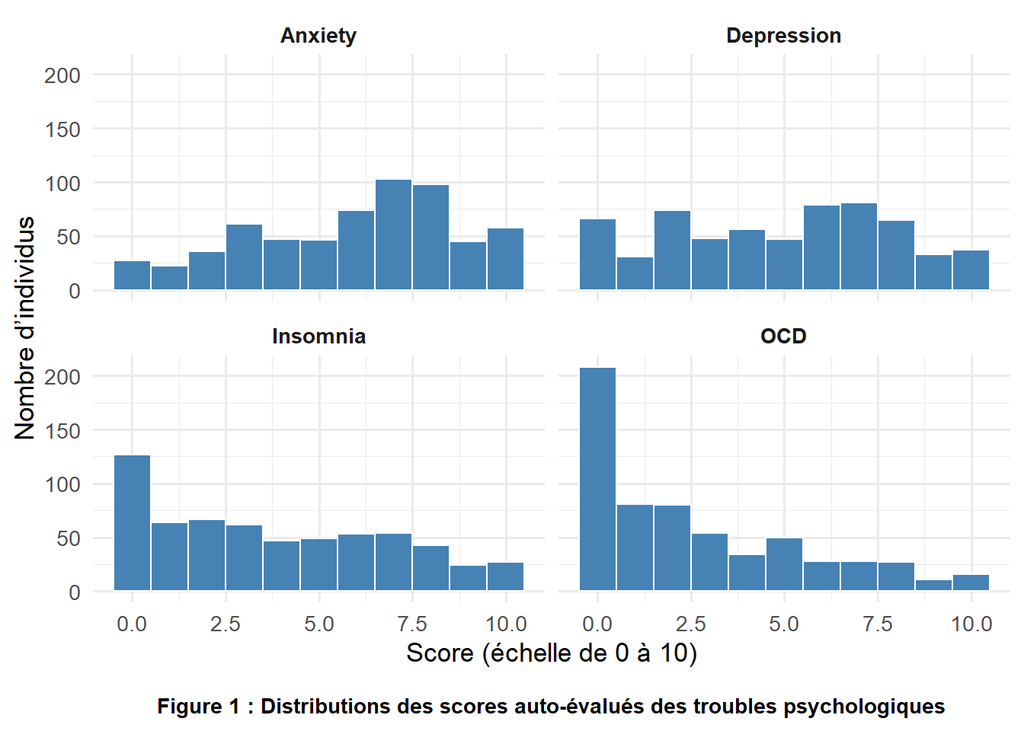

Enfin, pour clôturer cette partie descriptive, il est intéressant de se pencher sur la manière dont les participants perçoivent l’effet de la musique sur leur propre santé mentale.

Tableau 2 : Répartition des répondants selon leur perception de l’effet de la musique

| Effet perçu | Nombre de répondants | Pourcentage |
| --- | --- | --- |
| Improve | 463 | 75.7 % |
| No effect | 134 | 21.9 % |
| Worsen | 15 | 2.4 % |

Nous avons une statistique intéressante, **75,7% estiment que la musique a un effet positif** sur leur santé mentale. Nous allons donc regarder si les résultats de l’étude sont en adéquation avec leurs avis.

# 2 **Étude de données**

## 2.1 🎧 Effet du temps d’écoute sur les troubles psychologiques :

Nous avons dans un premier temps évalué l’effet du nombre d’heures d’écoute musicale par jour (Hours.per.day) sur quatre variables psychologiques : l’**insomnie**, la **dépression**, l’**anxiété**, et les **troubles obsessionnels compulsifs** (OCD). Pour cela, nous avons réalisé quatre régressions linéaires simples, chacune avec un trouble comme variable dépendante.

$Insomnia = \beta_0 + \beta_1 Hours.per.day + u$

Tableau 3 : Régression linéaire simple sur l’insomnie en fonction du nombre d’heures d’écoute par jour

| Variable | Estimate | Erreur std. | t | p-value | Seuil | R² ajusté |
| --- | --- | --- | --- | --- | --- | --- |
| (Intercept) | 3.233 | 0.212 | 15.244 | 0.000 | *** | 0.01565 |
| Hours.per.day | 0.162 | 0.049 | 3.285 | 0.001 | ** |  |

$Depression = \beta_0 + \beta_1 Hours.per.day + u$

Tableau 4 : Régression linéaire simple sur la dépression en fonction du nombre d’heures d’écoute par jour

| Variable | Estimate | Erreur std. | t | p-value | Seuil | R² ajusté |
| --- | --- | --- | --- | --- | --- | --- |
| (Intercept) | 4.32 | 0.204 | 21.167 | 0.000 | *** | 0.01662 |
| Hours.per.day | 0.16 | 0.047 | 3.378 | 0.001 | *** |  |

Le lien entre le **temps d’écoute musicale** et la **dépression** est *significatif et positif*. Les individus qui écoutent davantage de musique tendent à déclarer des niveaux de dépression plus élevés. Ici encore, bien que le lien soit statistiquement significatif, *la part de variance expliquée est limitée* (R² ajusté = 0.01662).

$Anxiety = \beta_0 + \beta_1 Hours.per.day + u$

Tableau 5 : Régression linéaire simple sur l’anxiété en fonction du nombre d’heures d’écoute par jour

Variable

Estimate

Erreur std.

t

p-value

Seuil

R² ajusté

(Intercept)

5.578

0.190

29.350

0.000

***

0.00468

Hours.per.day

0.087

0.044

1.974

0.049

Le **temps d’écoute quotidien** est *significativement et positivement* associé à l’**anxiété** (p < 0.05). Cela signifie que plus une personne écoute de la musique dans la journée, plus son score d’anxiété tend à être élevé. Toutefois, *la force de cette relation reste modérée* (R² = 0.00468), ce qui suggère que le temps d’écoute n’explique qu’une très faible partie de la variation de l’anxiété.

$OCD = \beta_0 + \beta_1 Hours.per.day + u$

Tableau 6 : Régression linéaire simple sur les TOC en fonction du nombre d’heures d’écoute par jour

| Variable | Estimate | Erreur std. | t | p-value | Seuil | R² ajusté |
| --- | --- | --- | --- | --- | --- | --- |
| (Intercept) | 2.111 | 0.195 | 10.843 | 0.000 | *** | 0.0163 |
| Hours.per.day | 0.151 | 0.045 | 3.347 | 0.001 | *** |  |

Enfin, une association significative est aussi observée entre le **temps d’écoute** et les scores de **troubles obsessionnels compulsifs (TOC)**. Le modèle montre un *effet modéré* mais cohérent avec les résultats précédents, indiquant une tendance à des scores plus élevés en cas d’écoute prolongée.

> 🧠 **Interprétation globale :**

> Ces premiers résultats indiquent qu’il existe une *corrélation positive* entre le **temps passé à écouter de la musique chaque jour** et les **niveaux de quatre types de symptômes psychologiques**. Toutefois, il est important de souligner que la force des relations est faible (R² ajusté < 0.02), ce qui signifie que **d’autres variables non incluses dans ces modèles jouent un rôle plus important**.

## 2.2 🎷 Notre style musical influencerait-il notre santé mentale ?

Après de nombreux échecs à tester des régressions avec différentes variables dont les effets n’étaient pas significatifs, nous sommes tombés sur une piste de recherche, le **niveau de dépression** en fonction de la **fréquence d’écoute de certains genres de musique**, tels que le *rock* ou le *métal*.

### 2.2.1 *Régression linéaire sur la fréquence d’écoute du rock et du métal*

Nous testons d’abord l’effet de la **fréquence d’écoute du rock et du métal** sur le niveau de **dépression**.

$Depression = \beta_0 + \beta_1 \text{freq_rock} + \beta_2 \text{freq_metal} + u$

Tableau 7 : Régression linéaire multiple sur la dépression en fonction de la fréquence d’écoute du rock et du métal

Variable

Estimate

Erreur std.

t

p-value

Seuil

R² ajusté

(Intercept)

3.711

0.26

14.276

0.000

***

0.04239

freq_rock

0.415

0.13

3.183

0.002

freq_metal

0.258

0.12

2.157

0.031

Nous avons donc décidé d’approfondir cette piste de recherche en regroupant les genres *rock*, *métal*, *pop* et *hip-hop* dans une variable **freq_energique**, représente le niveau moyen d’écoute de musiques énergiques pour chaque répondant, sur une échelle de 0 à 3. Cette nouvelle variable fait donc la moyenne du niveau de réponse pour chaque genre inclus dans la variable. Nous avons fait pareil pour les musiques plus calmes comme le *classique* ou le *lofi* dans une variable nommée **freq_calme**.

### 2.2.2 *Regroupement en deux groupes, fréquence énergique et fréquence calme*

$Depression = \beta_0 + \beta_1 \text{freq_energique} + \beta_2 \text{freq_calme} + u$

Tableau 8 : Régression linéaire multiple sur la dépression en fonction de la fréquence d’écoute de musiques énergiques et de musiques calmes

| Variable | Estimate | Erreur std. | t | p-value | Seuil | R² ajusté |
| --- | --- | --- | --- | --- | --- | --- |
| (Intercept) | 2.833 | 0.382 | 7.409 | 0.000 | *** | 0.0555 |
| freq_energique | 1.206 | 0.196 | 6.139 | 0.000 | *** |  |
| freq_calme | 0.015 | 0.157 | 0.094 | 0.925 |  |  |

On remarque avec cette régression, après avoir regroupé les genres musicaux selon qu’il s’agisse de genres calmes (classique, lofi) ou énergiques (rock, métal, pop, hip-hop), que **les musiques énergiques ont un effet significatif sur le niveau de dépression**. En moyenne, l’augmentation d’un échelon de la fréquence d’écoute de musiques énergiques entraîne l’augmentation de 1,2 échelon sur le niveau de dépression. À l’inverse, **l’effet des musiques calmes n’est pas significatif sur le niveau de dépression**, nous pouvons donc oublier cette variable.

### 2.2.3 *Ajout de l’avis des répondants sur les effets de la musique*

Nous allons essayer d’inclure l’**avis subjectif** des répondants sur les **effets de la musique** sur leur santé mentale. La variable “Music.effects” peut prendre trois valeurs : “Worsen”, “No effect” ou “Improve”. Nous allons mettre *“No effect” en valeur de référence* pour nos régressions.

$Depression = \beta_0 + \beta_1 \text{freq_energique} + \beta_2 \text{music.effects} + u$

| Variable | Estimate | Erreur std. | t | p-value | Seuil | R² ajusté |
| --- | --- | --- | --- | --- | --- | --- |
| (Intercept) | 2.477 | 0.403 | 6.141 | 0.000 | *** | 0.07271 |
| freq_energique | 1.181 | 0.195 | 6.063 | 0.000 | *** |  |
| Music.effects | -0.517 | 1.314 | -0.393 | 0.694 |  |  |
| Music.effectsImprove | 0.470 | 0.282 | 1.665 | 0.096 | . |  |
| Music.effectsWorsen | 2.754 | 0.783 | 3.519 | 0.000 | *** |  |

Tableau 10 : Interprétation des résultats de la régression

| Variable | Estimate | p-value | Significatif (à 5%) | Interprétation |
| --- | --- | --- | --- | --- |
| Intercept | 2.48 | < 0.001 | ✓ | Score de dépression moyen pour une personne avec freq_energique = 0 et qui estime que la musique a “no effect”. |
| freq_energie | +1.18 | < 0.001 | ✓ | Chaque augmentation d’un point de la fréquence d’écoute de musiques énergiques est associée à +1.18 point de dépression en moyenne. (Effet significatif) |
| Music.effectsImprove | +0.47 | 0.096 | ✗ | Les individus qui estiment que la musique les aide (“improve”) ont un score de dépression 0.47 points plus élevé que ceux qui disent “no effect”, mais cet effet n’est significatif qu’à 10%. |
| Music.effectsWorsen | +2.75 | < 0.001 | ✓ | Ceux qui pensent que la musique empire leur état (“worsen”) ont en moyenne +2.75 points de dépression par rapport à ceux qui disent “no effect”. (Très significatif) |

### 2.2.4 *Ajout d’une interaction entre freq_energique et music.effects*

Dans la suite de cette analyse, nous allons tester si **l’impact de la musique énergique est plus fort** chez ceux qui disent qu’elle aggrave leur état grâce à **l’ajout d’une interaction** entre la variable *“freq_energique”* et *“music.effects”*.

$Depression = \beta_0 + \beta_1 \text{freq_energique} + \beta_2 \text{music.effects} + \beta_3 \text{freq_energique}*\text{music.effects} + u$

Tableau 11 : Régression linéaire multiple avec interaction entre la fréquence d’écoute de musiques énergiques et l’effet perçu de la musique sur la dépression

| Variable | Estimate | Erreur std. | t | p-value | Seuil | R² ajusté |
| --- | --- | --- | --- | --- | --- | --- |
| (Intercept) | 2.519 | 0.730 | 3.448 | 0.001 | *** | 0.07414 |
| freq_energique | 1.156 | 0.421 | 2.743 | 0.006 | ** |  |
| Music.effects | -0.019 | 3.957 | -0.005 | 0.996 |  |  |
| Music.effectsImprove | 0.592 | 0.837 | 0.708 | 0.479 |  |  |
| Music.effectsWorsen | -0.297 | 1.873 | -0.158 | 0.874 |  |  |
| freq_energique:Music.effects | -0.489 | 3.521 | -0.139 | 0.890 |  |  |
| freq_energique:Music.effectsImprove | -0.071 | 0.478 | -0.148 | 0.883 |  |  |
| freq_energique:Music.effectsWorsen | 1.831 | 1.025 | 1.787 | 0.074 | . |  |

Les résultats montrent que :

- Pour les individus qui déclarent que *la musique n’a aucun effet sur leur santé mentale* (catégorie de référence), une augmentation d’**un point dans la fréquence d’écoute de musiques énergiques** est associée à une **hausse moyenne de 1.16 point sur l’échelle de dépression**.
- Pour ceux qui perçoivent *la musique comme aggravant leur état* (Worsen), l’interaction avec “freq_energique” est **positive et significative à 10%**. Cela suggère que pour ces individus, l’effet des musiques énergiques sur la dépression serait encore plus fort.
- À l’inverse, pour ceux qui *estiment que la musique les aide* (Improve), l’interaction avec “freq_energique” **n’est pas significative**, ce qui indiquerait que l’effet de la musique énergique est comparable à celui observé dans la catégorie de référence (No effect).

> 📌 **Interprétation globale :**

> Ces résultats suggèrent que l’impact des musiques énergiques sur le niveau de dépression **varie en fonction de la sensibilité subjective des individus** à la musique. Les effets sont les plus marqués chez ceux qui considèrent que la musique **aggrave leur état**, ce qui souligne l’importance d’intégrer les dimensions perceptives dans l’étude des liens entre musique et santé mentale.

### 2.2.5 *Ajout de variables de contrôle telles que l’âge et le BPM*

Nous allons maintenant enrichir notre modèle en y ajoutant des **variables de contrôle** comme *l’âge des répondants* et *le BPM moyen des musiques écoutées*. Cela nous permet de tester si l’effet observé précédemment est robuste une fois ces facteurs pris en compte.

$Depression = \beta_0 + \beta_1 \text{freq_energique} + \beta_2 \text{music.effects} + \beta_3 \text{âge} + \beta_4 BPM + u$

Tableau 12 : Régression linéaire multiple incluant des variables de contrôle (âge et BPM)

| Variable | Estimate | Erreur std. | t | p-value | Seuil | R² ajusté |
| --- | --- | --- | --- | --- | --- | --- |
| (Intercept) | 2.709 | 0.642 | 4.218 | 0.000 | *** | 0.07103 |
| freq_energique | 1.160 | 0.197 | 5.886 | 0.000 | *** |  |
| Music.effects | -0.512 | 1.315 | -0.389 | 0.697 |  |  |
| Music.effectsImprove | 0.457 | 0.283 | 1.613 | 0.107 |  |  |
| Music.effectsWorsen | 2.731 | 0.784 | 3.483 | 0.001 | *** |  |
| Age | -0.010 | 0.010 | -0.932 | 0.352 |  |  |
| BPM | 0.000 | 0.003 | 0.120 | 0.904 |  |  |

**Pour conclure :**

- Bien que ces deux variables ne présentent **pas d’effet significatif** direct sur le niveau de dépression dans notre modèle, leur inclusion est essentielle pour éviter un biais **d’omission de variable**. Autrement dit, nous nous assurons que l’effet principal observé n’est pas simplement dû à l’influence cachée d’autres facteurs.
- Le résultat est clair : l’effet de la musique énergique reste **significatif** après l’ajout de ces contrôles, ce qui confirme la **solidité** et la **stabilité** du lien principal mis en évidence.

## 2.3 🏆 Choix du modèle préféré :

Après avoir testé plusieurs régressions simples et multiples, nous avons retenu comme modèle préféré la régression suivante :

$Depression = \beta_0 + \beta_1 \text{freq_energique} + \beta_2 \text{music.effects} + \beta_3 \text{âge} + \beta_4 BPM + u$

Ce modèle permet de prédire le niveau autoévalué de dépression en fonction de :

- la **fréquence d’écoute de musiques énergiques** (freq_energique) ;
- la **perception subjective de l’effet de la musique** (Music.effects) ;
- deux **variables de contrôle** individuelles (Âge et BPM).

**Raisons du choix :**

🎯 **Pertinence théorique :** le modèle prend en compte à la fois le comportement musical objectif (fréquence d’écoute par genre) et la perception subjective des effets de la musique, ce qui est central dans notre problématique.

🔍 **Robustesse :** l’effet de la musique énergique reste statistiquement significatif même après ajout de variables de contrôle, ce qui valide sa stabilité.

🧠 **Lisibilité :** contrairement au modèle avec interaction (plus complexe), ce modèle reste facile à interpréter et à expliquer, tout en intégrant plusieurs dimensions pertinentes.

📊 **Puissance explicative correcte :** bien que le R² ajusté reste modéré (~0.07), ce modèle explique davantage de variance que les régressions simples, tout en évitant le sur-ajustement.

## 2.4 📌 Questionnement sur l’endogénéité et les limites de notre base de données :

> ⚠️️ L’ensemble des données utilisées dans notre analyse provient d’un questionnaire Google Forms rempli de manière volontaire et anonyme par des internautes. Ainsi, bien que la base soit riche et variée, elle **ne repose pas sur un échantillon aléatoire ou représentatif**, ce qui limite sa portée scientifique.

> Notre objectif est de proposer une **analyse économétrique rigoureuse** à partir de ces données, tout en étant conscient des limites méthodologiques, en particulier des risques **d’endogénéité**, qui peuvent affecter la validité des résultats.

### 2.4.1 *Problèmes potentiels d’endogénéité*

L’endogénéité survient lorsqu’une **ou plusieurs variables explicatives** sont **corrélées au terme d’erreur**, ce qui viole une des hypothèses fondamentales du modèle de régression linéaire. Voici **trois causes classiques** que nous devons garder à l’esprit :

- 🔁 **Causalité inverse** : il est possible que **l’écoute de musique influence la santé mentale**, mais également que **l’état de santé mentale d’un individu influence son temps d’écoute** (ex : une personne déprimée écoute plus de musique pour se réconforter).
- ❓ **Variable omise** : si des facteurs non observés comme des **troubles psychologiques passés, un environnement familial difficile ou des traits de personnalité** influencent à la fois la santé mentale et les habitudes musicales, cela crée un biais.
- 🎯 **Erreur de mesure** : les niveaux d’anxiété, dépression, insomnie ou TOC sont **autoévalués par les répondants**, sans standardisation. Il existe donc une **variabilité individuelle dans l’interprétation de l’échelle**, ce qui introduit une incertitude dans les mesures.

### 2.4.2 *Pistes de solution : les variables instrumentales (VI)*

Une solution classique pour traiter l’endogénéité consiste à utiliser une **variable instrumentale**, qui permet d’isoler la partie “exogène” de la variable problématique.

Pour qu’une VI soit valide, elle doit :

- Être **corrélée à la variable explicative endogène** (ex : temps d’écoute ou fréquence de certains genres),
- Être **non corrélée au terme d’erreur**, c’est-à-dire n’avoir aucun effet direct sur la variable dépendante (la santé mentale), sauf via la variable explicative.

Dans notre cas, il est cependant difficile d’identifier une VI crédible à partir de la base de données disponible.

### 2.4.3 *Autre limite : l’hétéroscédasticité*

Enfin, notre modèle pourrait également souffrir d’**hétéroscédasticité** : c’est-à-dire que la **variance de l’erreur n’est pas constante** selon les niveaux d’une variable indépendante.  
Par exemple, on pourrait supposer que **les effets de la musique sur la dépression varient plus fortement chez les jeunes que chez les plus âgés**, créant une plus grande dispersion des résidus dans certains sous-groupes.

# 3 **Conclusion**

À travers cette étude, nous avons tenté de répondre à la question suivante :  
**Dans quelle mesure les habitudes d’écoute musicale influencent-elles la santé mentale auto-déclarée chez les individus ?**

Nos analyses économétriques, basées sur une base de données volontaire et non représentative, ont mis en lumière plusieurs résultats intéressants :

- Une **corrélation positive** existe entre le **temps d’écoute quotidien** et différents troubles psychologiques (dépression, anxiété, insomnie, TOC), bien que les effets soient faibles.
- Les **genres musicaux écoutés** semblent également jouer un rôle. En particulier, la **fréquence d’écoute de musiques énergiques** (rock, métal, pop, hip-hop) est **significativement associée à un niveau plus élevé de dépression** autoévaluée.
- Ce lien est **modulé par l’effet perçu de la musique** : les personnes affirmant que la musique aggrave leur état sont celles pour qui cet effet est le plus marqué.
- L’ajout de **variables de contrôle** telles que l’âge ou le BPM moyen permet de **valider la robustesse** du lien principal, même si ces variables ne sont pas elles-mêmes significatives.

Malgré ces résultats, plusieurs **limites méthodologiques** subsistent, en particulier concernant l’**endogénéité potentielle**, l’**autoévaluation subjective des troubles** et l’**absence de représentativité de l’échantillon**.  
⚠️ Ces limites invitent à **interpréter les résultats avec prudence** et à envisager des études complémentaires, sur des données plus structurées et représentatives.

En somme, ce projet montre que la musique, bien que bénéfique pour beaucoup, peut être vécue différemment selon les individus et leur état psychologique. Cela ouvre la voie à des pistes de réflexion intéressantes sur la **personnalisation de la musique comme outil thérapeutique ou préventif**.